# Breast Cancer Proteomics

27 April, 2020

## Dataset

[figure not shown]

## Key concepts

- **iTRAQ:** A novel, MS-based approach for the relative quantification of proteins
- **TCGA:** The Cancer Genome Atlas (TCGA), a landmark cancer genomics program
- **CPTAC:** The National Cancer Institute’s Clinical Proteomic Tumor Analysis Consortium (CPTAC)
- **PAM50:** The PAM50 classifier is widely used for breast tumor intrinsic subtyping based on gene expression

## Aim:

As rate of oncological diseases in the world keeps rising, there is an increased need for better diagnostic tools and treatments.

- **Key aims** : To use the TCGA Breat Cancer proteomic dataset that is accompanied by clinical observations and apply reproducible research methodology to:
  - Explore the dataset for **patterns** between the *clinical* and *expression* data
  - Apply Machine Learning techniques to **create models** to help identify the *Tumor subclasses*
- **Additionally**:
  - To apply reproducible research methodology while conducting this project

## Importance

**Importance**

- DIAGNOSTICS:
  - new methods for tumor typing
  - more accurate course of treatments
  - new biomarkers for diagnostics
- DRUG:
  - new targets for treatment
  - increased treatment efficacy
- RESEARCH:
  - treatment effects treatment on tumor landscapes

## Data Overview 1/3

### Clinical Data

```
## [1] 105  30
```

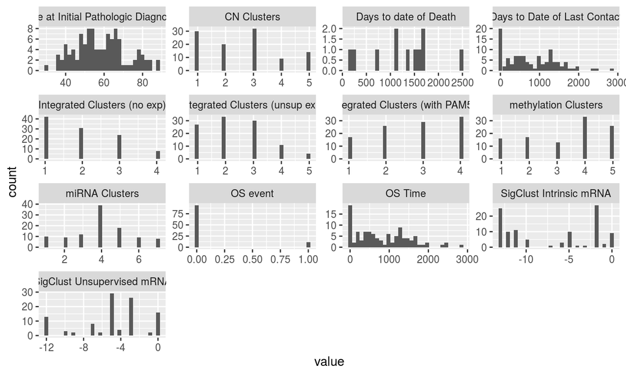

## Data Overview 2/3

### Expression Data

```
## [1] 12553    86
```

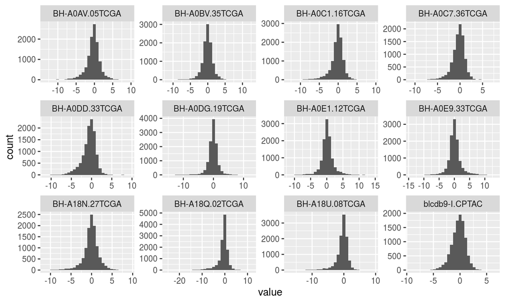

## Data Overview 3/3

### PAM50 panel

```
## [1] "Dimentions:"
```

```
## [1] 100   4
```

```
## [1] "GeneSymbol"      "RefSeqProteinID" "Species"         "Gene Name"
```

## Exploratory analysis:

Potential patterns from the phenotype data: - Clinical observations:

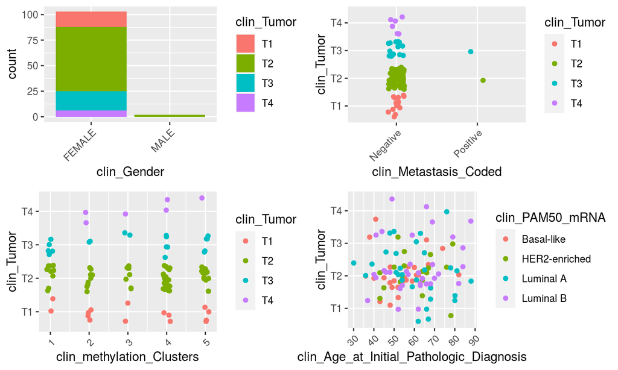

## Data Preparation: Joining

Combining Clinical data and Expression data based on patient IDs - dropping the unmatched observations

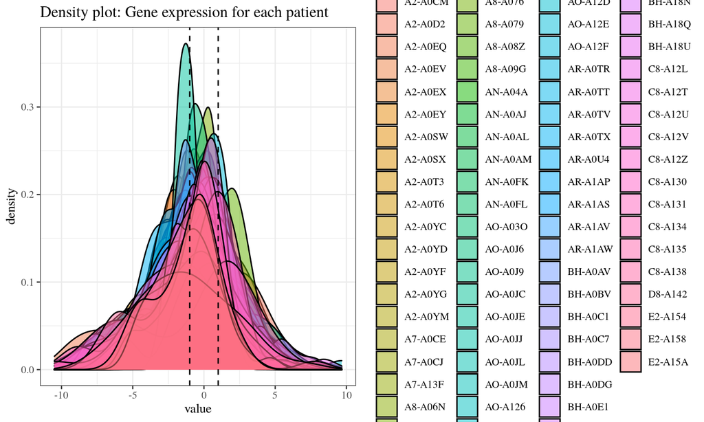

## Tissue specific expression landscape

### Heatmap

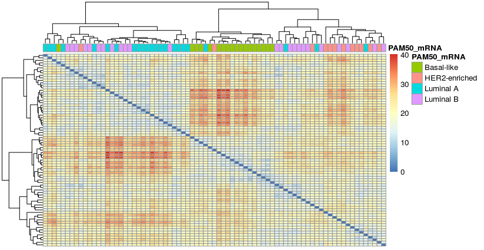

## Gene Ontology landscape

Explore the gene clustering profiles using Gene ontology PANTHER resourse

[figure not shown]

## Modelling data: PCA

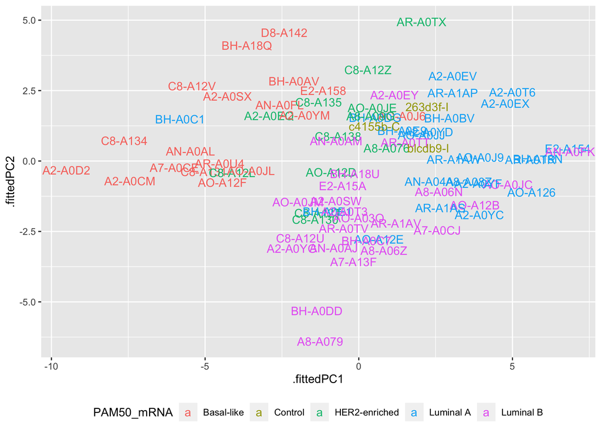

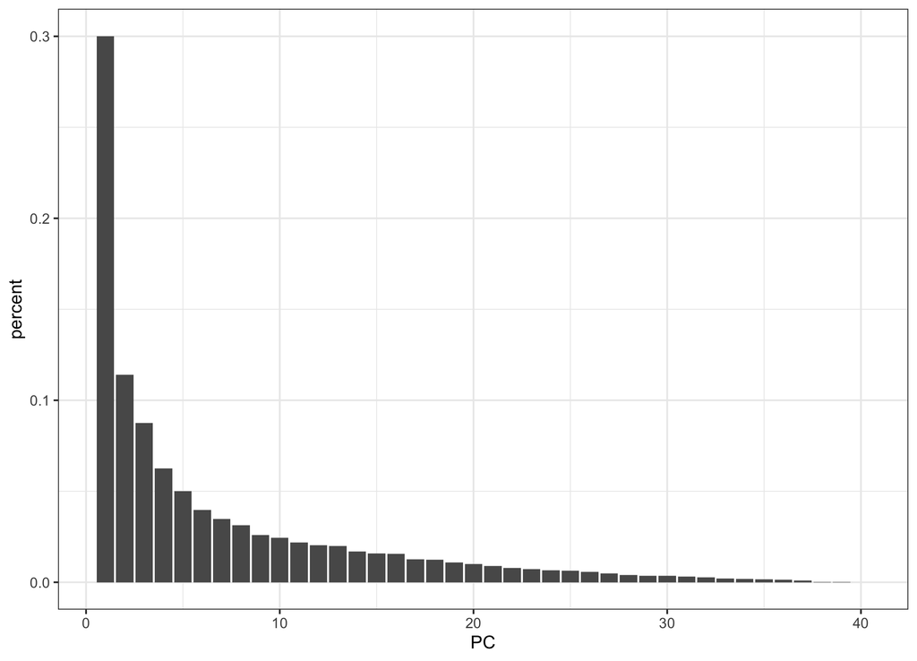

## ANN model confusion matrix

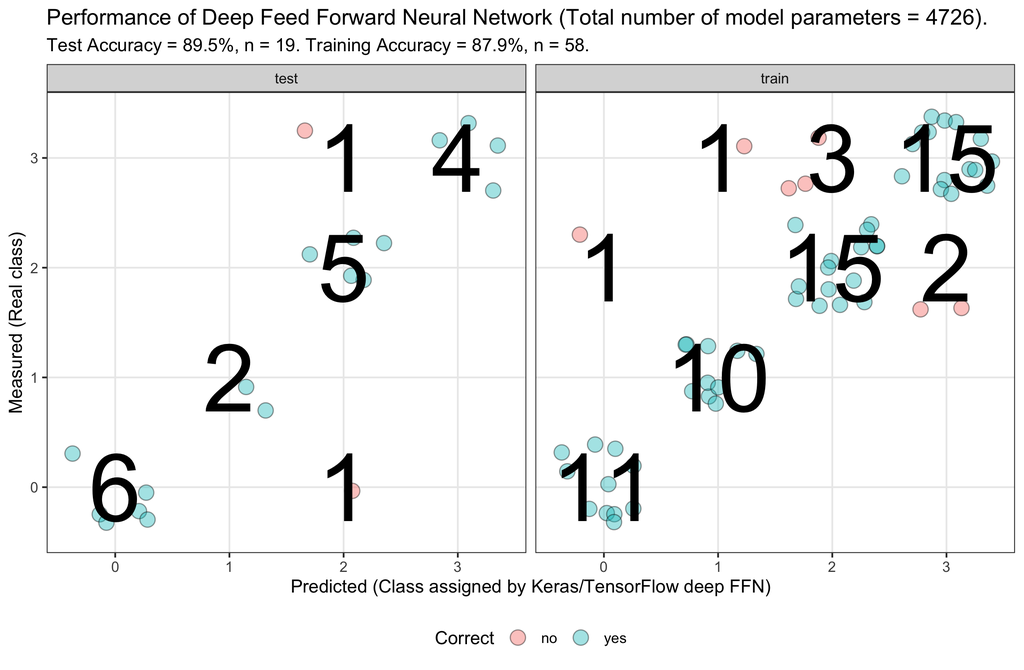

## Other modelling

- in progress:
  - Classification tree (supervised)
  - Clustering (knn)
  - Linear model ( Only AGE as a continuous variable )
  - Logistic regression (multiclass)

## Shiny application

Currently working as an **Interactive Heatmap**

[figure not shown]

## Current “file” state

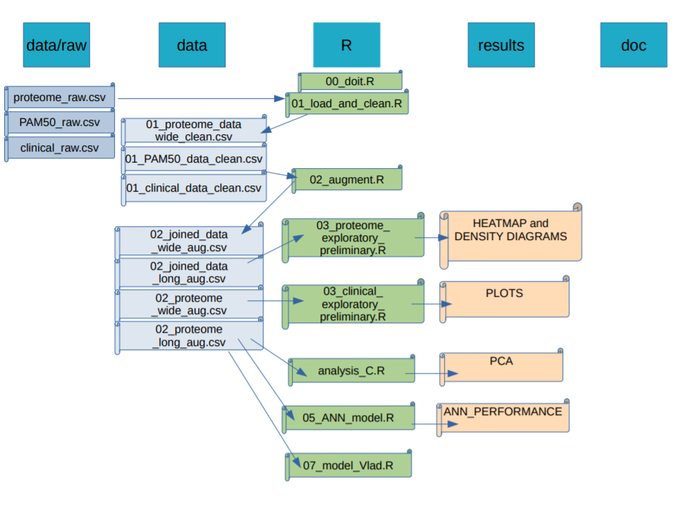

## Are we on track ?

[figure not shown]